# Data_preparation

Maohua Nie

2023-11-27

### Basic infomation of pilot data

Data were planned to be collected from 150 participants. Now 150 in total.

#### Demographics of participants

Average age: 38.3, 45 female and 99 male, 5 Non-binary and 1 other.

| Prolific_ID | gender | education | age | feedback |
| --- | --- | --- | --- | --- |
| 54247957fdf99b691fb38467 | Female | Post-graduate degree | 45 | n/a |
| 542bdb6dfdf99b324ea37c3a | Male | College or university | 53 | no |
| 5460ef52fdf99b49ea4b5906 | Male | Post-graduate degree | 41 | It was quite unique. |
| 559272f4fdf99b7e42e96932 | Male | College or university | 53 | interesting study. good luck with the results. |
| 568a7774316b10000c506283 | Male | Secondary school up to 16 years | 39 | No |
| 56b12c0e9f1826000cbcc76c | Female | Higher or secondary or further education (A-levels, BTEC, etc.) | 35 | no |
| 56c10b2eeb5b2200065baa08 | Female | Post-graduate degree | 48 | Good luck with your research |
| 56d1f7f67bbc32000589a588 | Female | Higher or secondary or further education (A-levels, BTEC, etc.) | 20 | None |
| 57732cfcda75d30001487571 | Male | Higher or secondary or further education (A-levels, BTEC, etc.) | 29 |  |
| 57b76ef5017c2d000166f019 | Male | College or university | 24 | thanks for the study |
| 57b77ad86615e5000160ea97 | Female | Post-graduate degree | 34 | no |
| 57d0db6cf7bcd90001cd47bc | Male | Secondary school up to 16 years | 49 | Enjoyable,interesting experiment to participate in. |
| 58584aa98604ae000165e633 | Female | Higher or secondary or further education (A-levels, BTEC, etc.) | 52 | no |
| 590203d0fb96b90001dddae0 | Male | College or university | 42 | No |
| 5915e5c6405db80001f30ff1 | Female | Secondary school up to 16 years | 37 | none |
| 592220f8fc043000016c5aeb | Male | Secondary school up to 16 years | 38 | everything was fine, thanks |
| 594abd98215cbd000146debc | Female | Secondary school up to 16 years | 55 | Interesting study |
| 595d3afcdd044900012ce78a | Male | Higher or secondary or further education (A-levels, BTEC, etc.) | 54 | no |
| 59c2fa00e3a73b00011a8e34 | Male | College or university | 54 | no |
| 59d585d3d1ab390001da2f35 | Male | College or university | 43 | No comment |
| 5a15f9a0844c7a00015e5bca | Female | College or university | 53 | no |
| 5a46a038ee927b0001e1e6f5 | Male | College or university | 40 | n/a |
| 5a5bd24be0cf3d000126849e | Female | College or university | 46 | Thank you |
| 5a68e1d435f26b0001498c1a | Female | College or university | 35 | No |
| 5a8185b8aa46dd00016b80d6 | Female | College or university | 53 | no |
| 5aae93f5fb22320001baaaac | Female | College or university | 51 | this was very engaging even though i didnt do very well |
| 5acb92e9e1099600016ad073 | Female | College or university | 35 | N/A |
| 5ad0903b3a859300016c4e60 | Male | College or university | 36 | N/A |
| 5ad614eb33a3ab0001fa62cd | Female | College or university | 22 | n/a |
| 5af5f227672ea800010d3b8d | Male | College or university | 26 | no |

[output cut: 120 more lines]

Education level of the participants:

| education | count |
| --- | --- |
| Secondary school up to 16 years | 21 |
| Higher or secondary or further education (A-levels, BTEC, etc.) | 36 |
| College or university | 62 |
| Post-graduate degree | 30 |
| NA | 1 |

The accuracy of each participants in the design questions (three in total)

8 removed, so 142 left.

| Prolific_ID | attemps_to_pass_three_questions |
| --- | --- |
| 54247957fdf99b691fb38467 | 3 |
| 542bdb6dfdf99b324ea37c3a | 4 |
| 5460ef52fdf99b49ea4b5906 | 3 |
| 559272f4fdf99b7e42e96932 | 3 |
| 568a7774316b10000c506283 | 6 |
| 56b12c0e9f1826000cbcc76c | 4 |
| 56c10b2eeb5b2200065baa08 | 3 |
| 56d1f7f67bbc32000589a588 | 6 |
| 57732cfcda75d30001487571 | 4 |
| 57b76ef5017c2d000166f019 | 5 |
| 57b77ad86615e5000160ea97 | 5 |
| 57d0db6cf7bcd90001cd47bc | 3 |
| 58584aa98604ae000165e633 | 3 |
| 590203d0fb96b90001dddae0 | 3 |
| 5915e5c6405db80001f30ff1 | 3 |
| 592220f8fc043000016c5aeb | 3 |
| 594abd98215cbd000146debc | 4 |
| 595d3afcdd044900012ce78a | 5 |
| 59c2fa00e3a73b00011a8e34 | 9 |
| 59d585d3d1ab390001da2f35 | 3 |
| 5a15f9a0844c7a00015e5bca | 6 |
| 5a46a038ee927b0001e1e6f5 | 3 |
| 5a5bd24be0cf3d000126849e | 7 |
| 5a68e1d435f26b0001498c1a | 3 |
| 5a8185b8aa46dd00016b80d6 | 6 |
| 5aae93f5fb22320001baaaac | 3 |
| 5acb92e9e1099600016ad073 | 3 |
| 5ad0903b3a859300016c4e60 | 6 |
| 5ad614eb33a3ab0001fa62cd | 6 |
| 5af5f227672ea800010d3b8d | 4 |

[output cut: 120 more lines]

### CA results

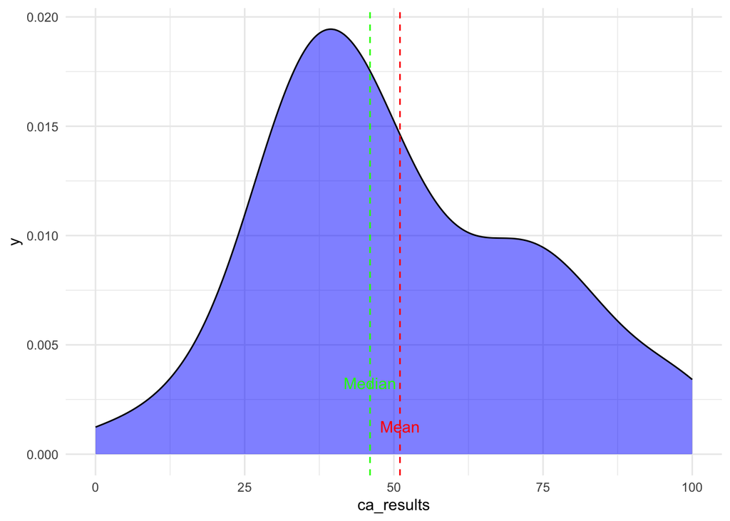

### RT of participants

Individual trials:

1. All trials that have a response time less than 1 second or more than 30 seconds
2. From the remaining trails we will exclude all trials with a response time greater than median + 3 SD or less than median – 3 SD, where the median is calculated individually for each participant and each condition (simple versus simple; complex versus complex; simple versus complex)
3. Participants for whom we remove more than 50% of trials will be completely removed

results: 10 removed, so 132 left.

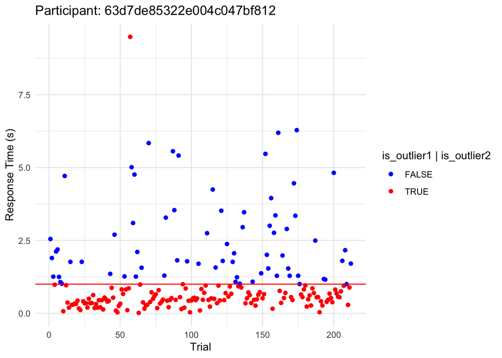

| Prolific_ID | remaining_trials | removed_trials |
| --- | --- | --- |
| 54247957fdf99b691fb38467 | 209 | 3 |
| 542bdb6dfdf99b324ea37c3a | 210 | 2 |
| 5460ef52fdf99b49ea4b5906 | 209 | 3 |
| 559272f4fdf99b7e42e96932 | 212 | 0 |
| 568a7774316b10000c506283 | 209 | 3 |
| 56b12c0e9f1826000cbcc76c | 209 | 3 |
| 56c10b2eeb5b2200065baa08 | 211 | 1 |
| 56d1f7f67bbc32000589a588 | 211 | 1 |
| 57732cfcda75d30001487571 | 207 | 5 |
| 57b76ef5017c2d000166f019 | 180 | 32 |
| 57b77ad86615e5000160ea97 | 204 | 8 |
| 57d0db6cf7bcd90001cd47bc | 212 | 0 |
| 58584aa98604ae000165e633 | 207 | 5 |
| 590203d0fb96b90001dddae0 | 208 | 4 |
| 5915e5c6405db80001f30ff1 | 200 | 12 |
| 592220f8fc043000016c5aeb | 209 | 3 |
| 594abd98215cbd000146debc | 209 | 3 |
| 595d3afcdd044900012ce78a | 206 | 6 |
| 59d585d3d1ab390001da2f35 | 212 | 0 |
| 5a15f9a0844c7a00015e5bca | 131 | 81 |
| 5a46a038ee927b0001e1e6f5 | 205 | 7 |
| 5a68e1d435f26b0001498c1a | 210 | 2 |
| 5a8185b8aa46dd00016b80d6 | 207 | 5 |
| 5aae93f5fb22320001baaaac | 207 | 5 |
| 5acb92e9e1099600016ad073 | 210 | 2 |
| 5ad0903b3a859300016c4e60 | 208 | 4 |
| 5ad614eb33a3ab0001fa62cd | 205 | 7 |
| 5af5f227672ea800010d3b8d | 211 | 1 |
| 5af6e439672ea800010d4e92 | 209 | 3 |
| 5b031e450a56660001284e2c | 209 | 3 |

[output cut: 111 more lines]

#### Hypothesis 1.1

One sample t test comparing the mean choice proportion of stochastic dominant option against the 50% benchmark for trials in each condition separately.

Expected results: The choice proportion of stochastic dominant option will be significantly greater than 50%.

Result table: check later in participants level

| Condition | t_value | df | p_value | conf_interval_lower | conf_interval_upper |
| --- | --- | --- | --- | --- | --- |
| cc | 25.59622 | 131 | 0 | 0.8372964 | 0.8938002 |
| ss | 38.85180 | 131 | 0 | 0.9041732 | 0.9475404 |
| cs | 33.32546 | 131 | 0 | 0.8515429 | 0.8959127 |

#### Hypothesis 1.2

One sample t test comparing the mean choice proportion of complex options against the 50% benchmark for trials in simple versus complex conditions.

Expected results: The choice proportion of complex option will be significantly lower than 50%.

Results table:

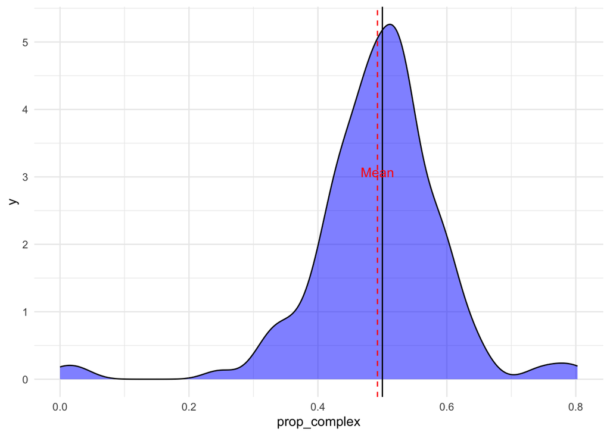

|  | Condition | mean | t_value | df | p_value | conf_interval_lower | conf_interval_upper |
| --- | --- | --- | --- | --- | --- | --- | --- |
| mean of x | cs | 0.4924038 | -0.8388395 | 131 | 0.4030874 | 0.4744895 | 0.510318 |

#### Hypothesis 1.3

Results:

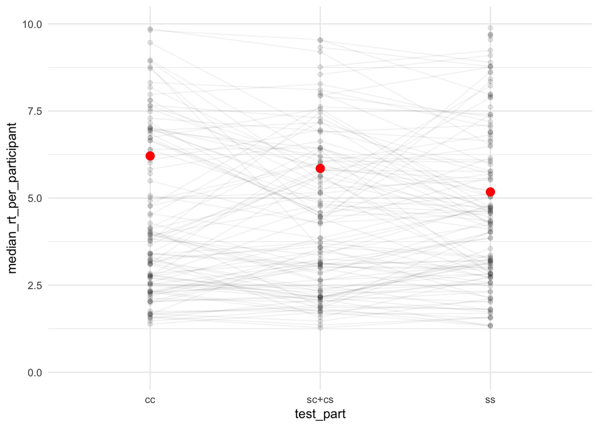

|  | Condition | median_cc | median_ss | t_value | df | p_value | conf_interval_lower | conf_interval_upper |
| --- | --- | --- | --- | --- | --- | --- | --- | --- |
| t | cc vs. ss median rt | 6.209909 | 5.176561 | 5.835188 | 131 | 0 | 0.6830239 | 1.383673 |

We expect higher Coefficient of EV in simple versus simple condition than in complex versus complex condition.

• Two-sample t test comparing percentage of risky choices in simple versus simple condition against complex versus complex condition. We have no theoretical reasons to expect a significant difference when we assume that complexity might increase processing noise equally for risky and not the risky (in terms of variance) options.

|  | Condition | cc_mean | ss_mean | t_value | df | p_value | conf_interval_lower | conf_interval_upper |
| --- | --- | --- | --- | --- | --- | --- | --- | --- |
| t | risky choice proportion in cc and ss | 0.4858764 | 0.4574342 | -3.496096 | 131 | 0.000645 | -0.0445359 | -0.0123484 |

### Correlation Hypotheses

Hypothesis 4.1: Pearson correlation test between percentage of complex choices in the condition simple versus complex and averaged cognitive ability test scores

We expect positive correlation

|  | Estimate | P_Value | Confidence_Interval_Lower | Confidence_Interval_Upper |
| --- | --- | --- | --- | --- |
| cor | 0.0374414 | 0.6699427 | -0.1342902 | 0.2069895 |

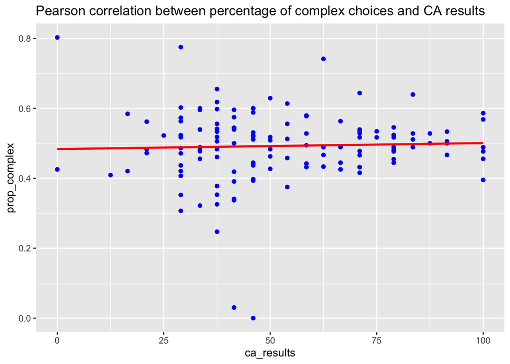

### skewness test

separate t-tests for just the subset of trials were the complex option is right-skwed as well as for the subset of trials were the complex option is left-skewed.

Also in the cc and ss conditions, test the choice proportion of option A when option A is right-skwed or left-skwed

Result Table of cs condition:

|  | Condition | right_mean | left_mean | t_value | df | p_value | conf_interval_lower | conf_interval_upper |
| --- | --- | --- | --- | --- | --- | --- | --- | --- |
| t | complex choice proportion when complex is right or left skewed | 0.6259546 | 0.3356098 | 8.408476 | 131 | 0 | 0.2220362 | 0.3586534 |

people seems to prefer right-skewed complex option but hate left-skewed complex option.

right-skewed means the probability of lower outcome is > .80

The plot of choice proportion:

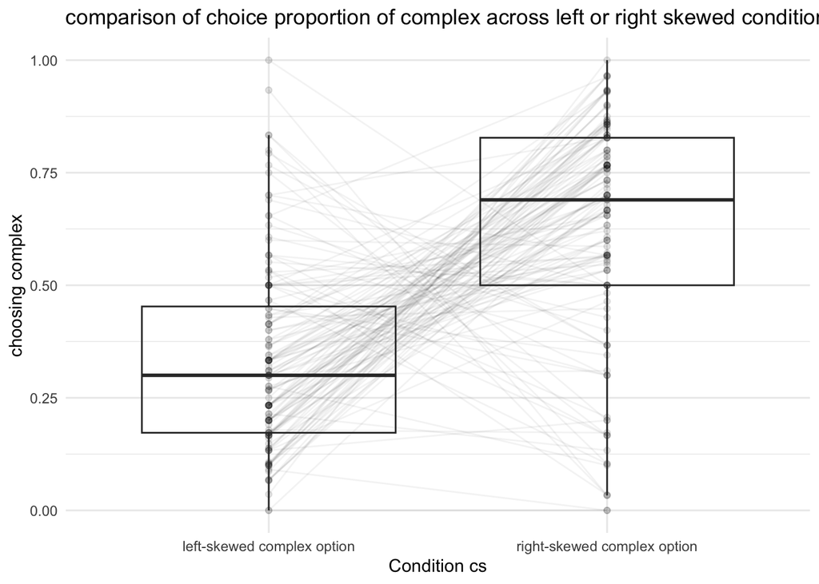

Also in the cc condition people seems to prefer right-skewed option A but hate left-skewed option A.

|  | Condition | right_mean | left_mean | t_value | df | p_value | conf_interval_lower | conf_interval_upper |
| --- | --- | --- | --- | --- | --- | --- | --- | --- |
| t | choice proportion when option A is right or left skewed in cc condition | 0.7205621 | 0.2385975 | 13.93239 | 131 | 0 | 0.4135312 | 0.550398 |

| evd_bins | sdd_bins | prop_A | count |
| --- | --- | --- | --- |
| -19 to -21 | 4 to 6 | 0.1209677 | 124 |
| -19 to -21 | 9 to 11 | 0.1250000 | 128 |
| -19 to -21 | 14 to 16 | 0.1250000 | 128 |
| -9 to -11 | 4 to 6 | 0.1484375 | 128 |
| -9 to -11 | 9 to 11 | 0.0859375 | 128 |
| -9 to -11 | 14 to 16 | 0.1153846 | 130 |
| 1 to -1 | 4 to 6 | 0.1472868 | 129 |
| 1 to -1 | 9 to 11 | 0.2230769 | 130 |
| 1 to -1 | 14 to 16 | 0.1904762 | 126 |
| 11 to 9 | 4 to 6 | 0.3228346 | 127 |
| 11 to 9 | 9 to 11 | 0.1680000 | 125 |
| 11 to 9 | 14 to 16 | 0.3076923 | 130 |
| 19 to 21 | 4 to 6 | 0.5793651 | 126 |
| 19 to 21 | 9 to 11 | 0.3629032 | 124 |
| 19 to 21 | 14 to 16 | 0.5503876 | 129 |

| evd_bins | sdd_bins | prop_A | count |
| --- | --- | --- | --- |
| -19 to -21 | 4 to 6 | 0.6230769 | 130 |
| -19 to -21 | 9 to 11 | 0.4961240 | 129 |
| -19 to -21 | 14 to 16 | 0.6147541 | 122 |
| -9 to -11 | 4 to 6 | 0.3203125 | 128 |
| -9 to -11 | 9 to 11 | 0.5736434 | 129 |
| -9 to -11 | 14 to 16 | 0.6976744 | 129 |
| 1 to -1 | 4 to 6 | 0.7795276 | 127 |
| 1 to -1 | 9 to 11 | 0.7301587 | 126 |
| 1 to -1 | 14 to 16 | 0.7209302 | 129 |
| 11 to 9 | 4 to 6 | 0.8984375 | 128 |
| 11 to 9 | 9 to 11 | 0.8373984 | 123 |
| 11 to 9 | 14 to 16 | 0.8692308 | 130 |
| 19 to 21 | 4 to 6 | 0.9047619 | 126 |
| 19 to 21 | 9 to 11 | 0.8730159 | 126 |
| 19 to 21 | 14 to 16 | 0.8888889 | 126 |

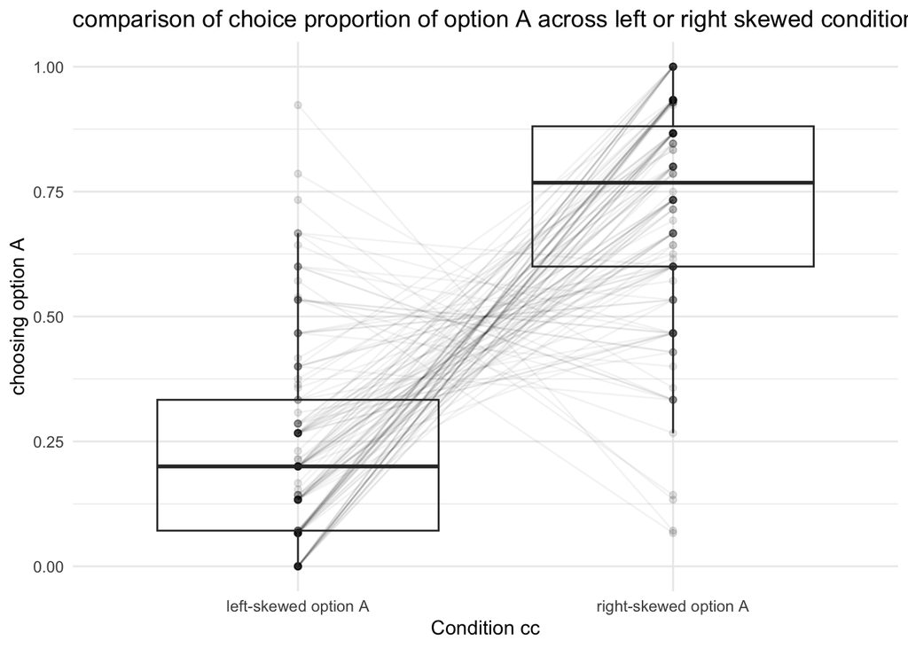

Also in ss condition there is a similar trend.

|  | Condition | right_mean | left_mean | t_value | df | p_value | conf_interval_lower | conf_interval_upper |
| --- | --- | --- | --- | --- | --- | --- | --- | --- |
| t | choice proportion when option A is right or left skewed in ss condition | 0.6530492 | 0.2476865 | 12.09164 | 131 | 0 | 0.3390438 | 0.4716816 |

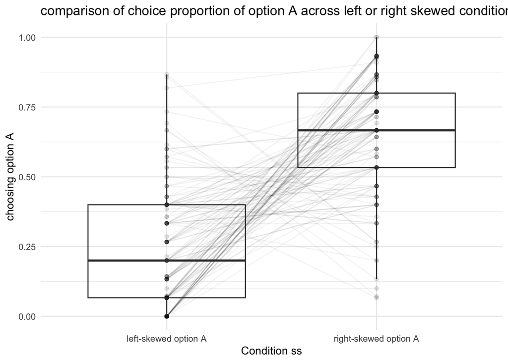

| evd_bins | sdd_bins | prop_A | count |
| --- | --- | --- | --- |
| -19 to -21 | 4 to 6 | 0.0944882 | 127 |
| -19 to -21 | 9 to 11 | 0.1692308 | 130 |
| -19 to -21 | 14 to 16 | 0.1484375 | 128 |
| -9 to -11 | 4 to 6 | 0.0866142 | 127 |
| -9 to -11 | 9 to 11 | 0.1162791 | 129 |
| -9 to -11 | 14 to 16 | 0.1550388 | 129 |
| 1 to -1 | 4 to 6 | 0.1889764 | 127 |
| 1 to -1 | 9 to 11 | 0.1923077 | 130 |
| 1 to -1 | 14 to 16 | 0.1732283 | 127 |
| 11 to 9 | 4 to 6 | 0.5156250 | 128 |
| 11 to 9 | 9 to 11 | 0.3750000 | 128 |
| 11 to 9 | 14 to 16 | 0.3548387 | 124 |
| 19 to 21 | 4 to 6 | 0.3730159 | 126 |
| 19 to 21 | 9 to 11 | 0.3461538 | 130 |
| 19 to 21 | 14 to 16 | 0.4076923 | 130 |

| evd_bins | sdd_bins | prop_A | count |
| --- | --- | --- | --- |
| -19 to -21 | 4 to 6 | 0.1484375 | 128 |
| -19 to -21 | 9 to 11 | 0.4645669 | 127 |
| -19 to -21 | 14 to 16 | 0.4761905 | 126 |
| -9 to -11 | 4 to 6 | 0.3840000 | 125 |
| -9 to -11 | 9 to 11 | 0.5781250 | 128 |
| -9 to -11 | 14 to 16 | 0.6171875 | 128 |
| 1 to -1 | 4 to 6 | 0.7286822 | 129 |
| 1 to -1 | 9 to 11 | 0.5905512 | 127 |
| 1 to -1 | 14 to 16 | 0.6976744 | 129 |
| 11 to 9 | 4 to 6 | 0.8412698 | 126 |
| 11 to 9 | 9 to 11 | 0.8425197 | 127 |
| 11 to 9 | 14 to 16 | 0.8702290 | 131 |
| 19 to 21 | 4 to 6 | 0.9236641 | 131 |
| 19 to 21 | 9 to 11 | 0.7812500 | 128 |
| 19 to 21 | 14 to 16 | 0.8449612 | 129 |

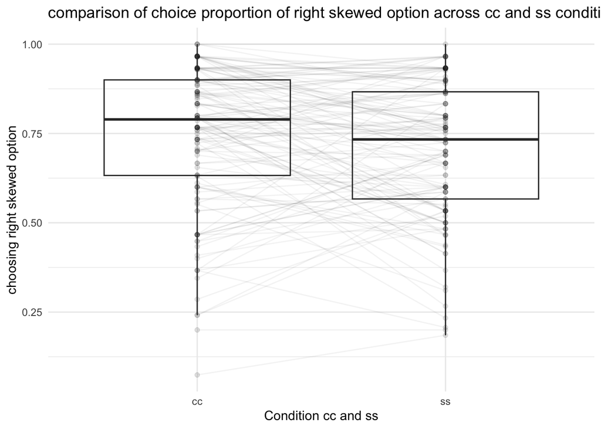

|  | Condition | cc_mean | ss_mean | t_value | df | p_value | conf_interval_lower | conf_interval_upper |
| --- | --- | --- | --- | --- | --- | --- | --- | --- |
| t | choices for right-skewed in cc and ss | 0.7411756 | 0.7023041 | 2.377527 | 131 | 0.0188749 | 0.0065282 | 0.0712148 |